# Risk Factor Analysis

## Outcome Variable

**Outcome Variable:** ever_stunted

## Predictor Variables

**Intervention Variable:** mbmi

**Adjustment Set:**

- arm
- W_mage
- meducyrs
- feducyrs
- single
- brthmon
- delta_W_mage
- delta_meducyrs
- delta_feducyrs
- delta_single
- delta_brthmon

## Stratifying Variables

The analysis was stratified on these variable(s):

- agecat
- studyid
- country

## Data Summary

| agecat | studyid | country | mbmi | ever_stunted | n_cell | n |
| --- | --- | --- | --- | --- | --- | --- |
| 0-6 months | ki0047075b-MAL-ED | BANGLADESH | [18.5-25) | 0 | 134 | 254 |
| 0-6 months | ki0047075b-MAL-ED | BANGLADESH | [18.5-25) | 1 | 29 | 254 |
| 0-6 months | ki0047075b-MAL-ED | BANGLADESH | <18.5 | 0 | 27 | 254 |
| 0-6 months | ki0047075b-MAL-ED | BANGLADESH | <18.5 | 1 | 5 | 254 |
| 0-6 months | ki0047075b-MAL-ED | BANGLADESH | [25-30) | 0 | 48 | 254 |
| 0-6 months | ki0047075b-MAL-ED | BANGLADESH | [25-30) | 1 | 5 | 254 |
| 0-6 months | ki0047075b-MAL-ED | BANGLADESH | >=30 | 0 | 2 | 254 |
| 0-6 months | ki0047075b-MAL-ED | BANGLADESH | >=30 | 1 | 4 | 254 |
| 0-6 months | ki0047075b-MAL-ED | BRAZIL | [18.5-25) | 0 | 79 | 221 |
| 0-6 months | ki0047075b-MAL-ED | BRAZIL | [18.5-25) | 1 | 9 | 221 |
| 0-6 months | ki0047075b-MAL-ED | BRAZIL | <18.5 | 0 | 8 | 221 |
| 0-6 months | ki0047075b-MAL-ED | BRAZIL | <18.5 | 1 | 2 | 221 |
| 0-6 months | ki0047075b-MAL-ED | BRAZIL | [25-30) | 0 | 74 | 221 |
| 0-6 months | ki0047075b-MAL-ED | BRAZIL | [25-30) | 1 | 8 | 221 |
| 0-6 months | ki0047075b-MAL-ED | BRAZIL | >=30 | 0 | 38 | 221 |
| 0-6 months | ki0047075b-MAL-ED | BRAZIL | >=30 | 1 | 3 | 221 |
| 0-6 months | ki0047075b-MAL-ED | INDIA | [18.5-25) | 0 | 115 | 242 |
| 0-6 months | ki0047075b-MAL-ED | INDIA | [18.5-25) | 1 | 27 | 242 |
| 0-6 months | ki0047075b-MAL-ED | INDIA | <18.5 | 0 | 40 | 242 |
| 0-6 months | ki0047075b-MAL-ED | INDIA | <18.5 | 1 | 9 | 242 |
| 0-6 months | ki0047075b-MAL-ED | INDIA | [25-30) | 0 | 36 | 242 |
| 0-6 months | ki0047075b-MAL-ED | INDIA | [25-30) | 1 | 4 | 242 |
| 0-6 months | ki0047075b-MAL-ED | INDIA | >=30 | 0 | 10 | 242 |
| 0-6 months | ki0047075b-MAL-ED | INDIA | >=30 | 1 | 1 | 242 |
| 0-6 months | ki0047075b-MAL-ED | NEPAL | [18.5-25) | 0 | 118 | 238 |
| 0-6 months | ki0047075b-MAL-ED | NEPAL | [18.5-25) | 1 | 16 | 238 |
| 0-6 months | ki0047075b-MAL-ED | NEPAL | [25-30) | 0 | 78 | 238 |
| 0-6 months | ki0047075b-MAL-ED | NEPAL | [25-30) | 1 | 9 | 238 |
| 0-6 months | ki0047075b-MAL-ED | NEPAL | >=30 | 0 | 15 | 238 |
| 0-6 months | ki0047075b-MAL-ED | NEPAL | >=30 | 1 | 2 | 238 |

[output cut: 338 more lines]

The following strata were considered:

- agecat: 0-24 months, studyid: ki0047075b-MAL-ED, country: BANGLADESH
- agecat: 0-24 months, studyid: ki0047075b-MAL-ED, country: BRAZIL
- agecat: 0-24 months, studyid: ki0047075b-MAL-ED, country: INDIA
- agecat: 0-24 months, studyid: ki0047075b-MAL-ED, country: NEPAL
- agecat: 0-24 months, studyid: ki0047075b-MAL-ED, country: PERU
- agecat: 0-24 months, studyid: ki0047075b-MAL-ED, country: SOUTH AFRICA
- agecat: 0-24 months, studyid: ki0047075b-MAL-ED, country: TANZANIA, UNITED REPUBLIC OF
- agecat: 0-24 months, studyid: ki1000304b-SAS-CompFeed, country: INDIA
- agecat: 0-24 months, studyid: ki1017093-NIH-Birth, country: BANGLADESH
- agecat: 0-24 months, studyid: ki1017093b-PROVIDE, country: BANGLADESH
- agecat: 0-24 months, studyid: ki1017093c-NIH-Crypto, country: BANGLADESH
- agecat: 0-24 months, studyid: ki1066203-TanzaniaChild2, country: TANZANIA, UNITED REPUBLIC OF
- agecat: 0-24 months, studyid: ki1112895-iLiNS-Zinc, country: BURKINA FASO
- agecat: 0-24 months, studyid: ki1119695-PROBIT, country: BELARUS
- agecat: 0-24 months, studyid: ki1126311-ZVITAMBO, country: ZIMBABWE
- agecat: 0-24 months, studyid: ki1148112-LCNI-5, country: MALAWI
- agecat: 0-6 months, studyid: ki0047075b-MAL-ED, country: BANGLADESH
- agecat: 0-6 months, studyid: ki0047075b-MAL-ED, country: BRAZIL
- agecat: 0-6 months, studyid: ki0047075b-MAL-ED, country: INDIA
- agecat: 0-6 months, studyid: ki0047075b-MAL-ED, country: NEPAL
- agecat: 0-6 months, studyid: ki0047075b-MAL-ED, country: PERU
- agecat: 0-6 months, studyid: ki0047075b-MAL-ED, country: SOUTH AFRICA
- agecat: 0-6 months, studyid: ki0047075b-MAL-ED, country: TANZANIA, UNITED REPUBLIC OF
- agecat: 0-6 months, studyid: ki1000304b-SAS-CompFeed, country: INDIA
- agecat: 0-6 months, studyid: ki1017093-NIH-Birth, country: BANGLADESH
- agecat: 0-6 months, studyid: ki1017093b-PROVIDE, country: BANGLADESH
- agecat: 0-6 months, studyid: ki1017093c-NIH-Crypto, country: BANGLADESH
- agecat: 0-6 months, studyid: ki1066203-TanzaniaChild2, country: TANZANIA, UNITED REPUBLIC OF
- agecat: 0-6 months, studyid: ki1119695-PROBIT, country: BELARUS
- agecat: 0-6 months, studyid: ki1126311-ZVITAMBO, country: ZIMBABWE
- agecat: 0-6 months, studyid: ki1148112-LCNI-5, country: MALAWI
- agecat: 6-24 months, studyid: ki0047075b-MAL-ED, country: BANGLADESH
- agecat: 6-24 months, studyid: ki0047075b-MAL-ED, country: BRAZIL
- agecat: 6-24 months, studyid: ki0047075b-MAL-ED, country: INDIA
- agecat: 6-24 months, studyid: ki0047075b-MAL-ED, country: NEPAL
- agecat: 6-24 months, studyid: ki0047075b-MAL-ED, country: PERU
- agecat: 6-24 months, studyid: ki0047075b-MAL-ED, country: SOUTH AFRICA
- agecat: 6-24 months, studyid: ki0047075b-MAL-ED, country: TANZANIA, UNITED REPUBLIC OF
- agecat: 6-24 months, studyid: ki1000304b-SAS-CompFeed, country: INDIA
- agecat: 6-24 months, studyid: ki1017093-NIH-Birth, country: BANGLADESH
- agecat: 6-24 months, studyid: ki1017093b-PROVIDE, country: BANGLADESH
- agecat: 6-24 months, studyid: ki1017093c-NIH-Crypto, country: BANGLADESH
- agecat: 6-24 months, studyid: ki1066203-TanzaniaChild2, country: TANZANIA, UNITED REPUBLIC OF
- agecat: 6-24 months, studyid: ki1112895-iLiNS-Zinc, country: BURKINA FASO
- agecat: 6-24 months, studyid: ki1119695-PROBIT, country: BELARUS
- agecat: 6-24 months, studyid: ki1126311-ZVITAMBO, country: ZIMBABWE
- agecat: 6-24 months, studyid: ki1148112-LCNI-5, country: MALAWI

### Dropped Strata

Some strata were dropped due to rare outcomes:

- agecat: 0-6 months, studyid: ki0047075b-MAL-ED, country: BANGLADESH
- agecat: 0-6 months, studyid: ki0047075b-MAL-ED, country: BRAZIL
- agecat: 0-6 months, studyid: ki0047075b-MAL-ED, country: INDIA
- agecat: 0-6 months, studyid: ki0047075b-MAL-ED, country: NEPAL
- agecat: 0-6 months, studyid: ki0047075b-MAL-ED, country: PERU
- agecat: 0-6 months, studyid: ki0047075b-MAL-ED, country: SOUTH AFRICA
- agecat: 0-6 months, studyid: ki0047075b-MAL-ED, country: TANZANIA, UNITED REPUBLIC OF
- agecat: 0-6 months, studyid: ki1000304b-SAS-CompFeed, country: INDIA
- agecat: 0-6 months, studyid: ki1017093-NIH-Birth, country: BANGLADESH
- agecat: 0-6 months, studyid: ki1017093b-PROVIDE, country: BANGLADESH
- agecat: 0-6 months, studyid: ki1017093c-NIH-Crypto, country: BANGLADESH
- agecat: 0-6 months, studyid: ki1066203-TanzaniaChild2, country: TANZANIA, UNITED REPUBLIC OF
- agecat: 0-6 months, studyid: ki1119695-PROBIT, country: BELARUS
- agecat: 0-6 months, studyid: ki1148112-LCNI-5, country: MALAWI
- agecat: 6-24 months, studyid: ki0047075b-MAL-ED, country: BANGLADESH
- agecat: 6-24 months, studyid: ki0047075b-MAL-ED, country: BRAZIL
- agecat: 6-24 months, studyid: ki0047075b-MAL-ED, country: INDIA
- agecat: 6-24 months, studyid: ki0047075b-MAL-ED, country: NEPAL
- agecat: 6-24 months, studyid: ki0047075b-MAL-ED, country: PERU
- agecat: 6-24 months, studyid: ki0047075b-MAL-ED, country: SOUTH AFRICA
- agecat: 6-24 months, studyid: ki0047075b-MAL-ED, country: TANZANIA, UNITED REPUBLIC OF
- agecat: 6-24 months, studyid: ki1000304b-SAS-CompFeed, country: INDIA
- agecat: 6-24 months, studyid: ki1017093-NIH-Birth, country: BANGLADESH
- agecat: 6-24 months, studyid: ki1017093b-PROVIDE, country: BANGLADESH
- agecat: 6-24 months, studyid: ki1017093c-NIH-Crypto, country: BANGLADESH
- agecat: 6-24 months, studyid: ki1148112-LCNI-5, country: MALAWI
- agecat: 0-24 months, studyid: ki0047075b-MAL-ED, country: BANGLADESH
- agecat: 0-24 months, studyid: ki0047075b-MAL-ED, country: BRAZIL
- agecat: 0-24 months, studyid: ki0047075b-MAL-ED, country: NEPAL
- agecat: 0-24 months, studyid: ki0047075b-MAL-ED, country: PERU
- agecat: 0-24 months, studyid: ki0047075b-MAL-ED, country: SOUTH AFRICA
- agecat: 0-24 months, studyid: ki0047075b-MAL-ED, country: TANZANIA, UNITED REPUBLIC OF
- agecat: 0-24 months, studyid: ki1000304b-SAS-CompFeed, country: INDIA
- agecat: 0-24 months, studyid: ki1148112-LCNI-5, country: MALAWI

## Methods Detail

We’re interested in the causal parameters $E[Y_a]$ for all values of $a \in \mathcal{A}$. These parameters represent the mean outcome if, possibly contrary to fact, we intervened to set all units to have $A=a$. Under the randomization and positivity assumptions, these are identified by the statistical parameters $\psi_a=E_W[E_{Y|A,W}(Y|A=a,W)]$. In addition, we’re interested in the mean of $Y$, $E[Y]$ under no intervention (the observed mean). We will estimate these parameters by using SuperLearner to fit the relevant likelihood factors – $E_{Y|A,W}(Y|A=a,W)$ and $p(A=a|W)$, and then updating our likelihood fit using a joint TMLE.

For unadjusted analyses ($W=\{\}$), initial likelihoods were estimated using Lrnr_glm to estimate the simple $E(Y|A)$ and Lrnr_mean to estimate $p(A)$. For adjusted analyses, a small library containing Lrnr_glmnet, Lrnr_xgboost, and Lrnr_mean was used.

Having estimated these parameters, we will then use the delta method to estimate relative risks and attributable risks relative to a prespecified baseline level of $A$.

# Results Detail

## Results Plots

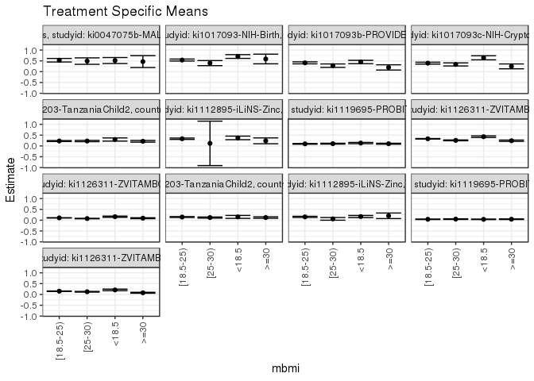

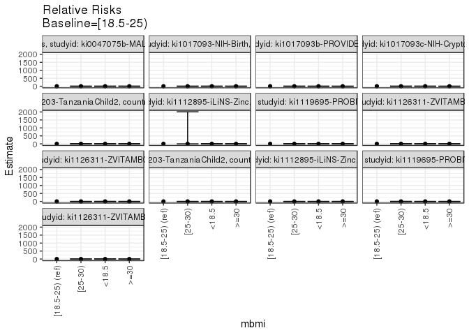

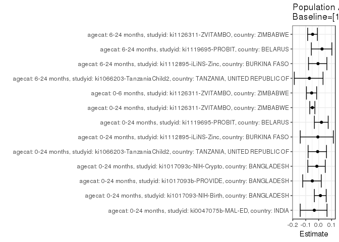

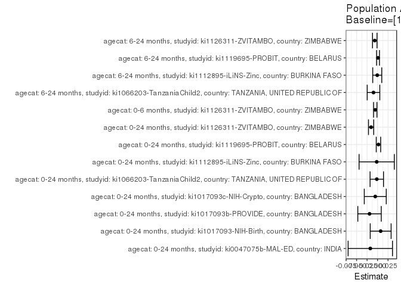

## Results Table

### Parameter: TSM

| agecat | studyid | country | intervention_level | baseline_level | estimate | ci_lower | ci_upper |
| --- | --- | --- | --- | --- | --- | --- | --- |
| 0-24 months | ki0047075b-MAL-ED | INDIA | [18.5-25) | NA | 0.5296843 | 0.4476457 | 0.6117229 |
| 0-24 months | ki0047075b-MAL-ED | INDIA | <18.5 | NA | 0.5160086 | 0.3777835 | 0.6542337 |
| 0-24 months | ki0047075b-MAL-ED | INDIA | [25-30) | NA | 0.4897043 | 0.3397524 | 0.6396562 |
| 0-24 months | ki0047075b-MAL-ED | INDIA | >=30 | NA | 0.4668939 | 0.1908330 | 0.7429548 |
| 0-24 months | ki1017093-NIH-Birth | BANGLADESH | [18.5-25) | NA | 0.5378988 | 0.4915991 | 0.5841985 |
| 0-24 months | ki1017093-NIH-Birth | BANGLADESH | <18.5 | NA | 0.7016311 | 0.6152352 | 0.7880269 |
| 0-24 months | ki1017093-NIH-Birth | BANGLADESH | [25-30) | NA | 0.3965829 | 0.2795013 | 0.5136645 |
| 0-24 months | ki1017093-NIH-Birth | BANGLADESH | >=30 | NA | 0.5872495 | 0.3639459 | 0.8105531 |
| 0-24 months | ki1017093b-PROVIDE | BANGLADESH | [18.5-25) | NA | 0.4092825 | 0.3627920 | 0.4557729 |
| 0-24 months | ki1017093b-PROVIDE | BANGLADESH | <18.5 | NA | 0.4480959 | 0.3705858 | 0.5256060 |
| 0-24 months | ki1017093b-PROVIDE | BANGLADESH | [25-30) | NA | 0.2783193 | 0.1993905 | 0.3572481 |
| 0-24 months | ki1017093b-PROVIDE | BANGLADESH | >=30 | NA | 0.1973351 | 0.0761611 | 0.3185092 |
| 0-24 months | ki1017093c-NIH-Crypto | BANGLADESH | [18.5-25) | NA | 0.3948796 | 0.3513514 | 0.4384077 |
| 0-24 months | ki1017093c-NIH-Crypto | BANGLADESH | <18.5 | NA | 0.6430232 | 0.5483153 | 0.7377310 |
| 0-24 months | ki1017093c-NIH-Crypto | BANGLADESH | [25-30) | NA | 0.3359967 | 0.2648674 | 0.4071260 |
| 0-24 months | ki1017093c-NIH-Crypto | BANGLADESH | >=30 | NA | 0.2459010 | 0.1339319 | 0.3578700 |
| 0-24 months | ki1066203-TanzaniaChild2 | TANZANIA, UNITED REPUBLIC OF | [18.5-25) | NA | 0.2274015 | 0.2042594 | 0.2505437 |
| 0-24 months | ki1066203-TanzaniaChild2 | TANZANIA, UNITED REPUBLIC OF | <18.5 | NA | 0.2971314 | 0.2236002 | 0.3706627 |
| 0-24 months | ki1066203-TanzaniaChild2 | TANZANIA, UNITED REPUBLIC OF | [25-30) | NA | 0.2269467 | 0.1967953 | 0.2570981 |
| 0-24 months | ki1066203-TanzaniaChild2 | TANZANIA, UNITED REPUBLIC OF | >=30 | NA | 0.2152279 | 0.1755473 | 0.2549085 |
| 0-24 months | ki1112895-iLiNS-Zinc | BURKINA FASO | [18.5-25) | NA | 0.3335104 | 0.3010227 | 0.3659981 |
| 0-24 months | ki1112895-iLiNS-Zinc | BURKINA FASO | <18.5 | NA | 0.3708498 | 0.2886597 | 0.4530400 |
| 0-24 months | ki1112895-iLiNS-Zinc | BURKINA FASO | [25-30) | NA | 0.1189183 | -0.9077333 | 1.1455699 |
| 0-24 months | ki1112895-iLiNS-Zinc | BURKINA FASO | >=30 | NA | 0.2354774 | 0.1007454 | 0.3702095 |
| 0-24 months | ki1119695-PROBIT | BELARUS | [18.5-25) | NA | 0.0967804 | 0.0801093 | 0.1134514 |
| 0-24 months | ki1119695-PROBIT | BELARUS | <18.5 | NA | 0.1321263 | 0.1030431 | 0.1612094 |
| 0-24 months | ki1119695-PROBIT | BELARUS | [25-30) | NA | 0.1043991 | 0.0834909 | 0.1253073 |
| 0-24 months | ki1119695-PROBIT | BELARUS | >=30 | NA | 0.1014736 | 0.0783590 | 0.1245881 |
| 0-24 months | ki1126311-ZVITAMBO | ZIMBABWE | [18.5-25) | NA | 0.3313191 | 0.3200727 | 0.3425655 |
| 0-24 months | ki1126311-ZVITAMBO | ZIMBABWE | <18.5 | NA | 0.4265050 | 0.3881812 | 0.4648287 |
| 0-24 months | ki1126311-ZVITAMBO | ZIMBABWE | [25-30) | NA | 0.2573171 | 0.2381289 | 0.2765052 |
| 0-24 months | ki1126311-ZVITAMBO | ZIMBABWE | >=30 | NA | 0.2397869 | 0.2081665 | 0.2714074 |
| 0-6 months | ki1126311-ZVITAMBO | ZIMBABWE | [18.5-25) | NA | 0.1070661 | 0.0996726 | 0.1144597 |
| 0-6 months | ki1126311-ZVITAMBO | ZIMBABWE | <18.5 | NA | 0.1605586 | 0.1316210 | 0.1894961 |
| 0-6 months | ki1126311-ZVITAMBO | ZIMBABWE | [25-30) | NA | 0.0756326 | 0.0639461 | 0.0873190 |
| 0-6 months | ki1126311-ZVITAMBO | ZIMBABWE | >=30 | NA | 0.0920128 | 0.0702843 | 0.1137413 |
| 6-24 months | ki1066203-TanzaniaChild2 | TANZANIA, UNITED REPUBLIC OF | [18.5-25) | NA | 0.1451920 | 0.1230136 | 0.1673703 |
| 6-24 months | ki1066203-TanzaniaChild2 | TANZANIA, UNITED REPUBLIC OF | <18.5 | NA | 0.1514072 | 0.0844799 | 0.2183346 |
| 6-24 months | ki1066203-TanzaniaChild2 | TANZANIA, UNITED REPUBLIC OF | [25-30) | NA | 0.1212420 | 0.0946854 | 0.1477986 |
| 6-24 months | ki1066203-TanzaniaChild2 | TANZANIA, UNITED REPUBLIC OF | >=30 | NA | 0.1219522 | 0.0868186 | 0.1570858 |
| 6-24 months | ki1112895-iLiNS-Zinc | BURKINA FASO | [18.5-25) | NA | 0.1527958 | 0.1261039 | 0.1794878 |
| 6-24 months | ki1112895-iLiNS-Zinc | BURKINA FASO | <18.5 | NA | 0.1682981 | 0.1194506 | 0.2171457 |
| 6-24 months | ki1112895-iLiNS-Zinc | BURKINA FASO | [25-30) | NA | 0.0614117 | -0.0012439 | 0.1240673 |
| 6-24 months | ki1112895-iLiNS-Zinc | BURKINA FASO | >=30 | NA | 0.2034548 | 0.0751474 | 0.3317621 |
| 6-24 months | ki1119695-PROBIT | BELARUS | [18.5-25) | NA | 0.0416535 | 0.0315637 | 0.0517433 |
| 6-24 months | ki1119695-PROBIT | BELARUS | <18.5 | NA | 0.0392903 | 0.0272102 | 0.0513704 |
| 6-24 months | ki1119695-PROBIT | BELARUS | [25-30) | NA | 0.0489616 | 0.0335994 | 0.0643238 |
| 6-24 months | ki1119695-PROBIT | BELARUS | >=30 | NA | 0.0446426 | 0.0308173 | 0.0584679 |
| 6-24 months | ki1126311-ZVITAMBO | ZIMBABWE | [18.5-25) | NA | 0.1494520 | 0.1396398 | 0.1592643 |
| 6-24 months | ki1126311-ZVITAMBO | ZIMBABWE | <18.5 | NA | 0.2081083 | 0.1714379 | 0.2447786 |
| 6-24 months | ki1126311-ZVITAMBO | ZIMBABWE | [25-30) | NA | 0.1231924 | 0.1068808 | 0.1395041 |
| 6-24 months | ki1126311-ZVITAMBO | ZIMBABWE | >=30 | NA | 0.0765887 | 0.0550812 | 0.0980963 |

### Parameter: E(Y)

| agecat | studyid | country | intervention_level | baseline_level | estimate | ci_lower | ci_upper |
| --- | --- | --- | --- | --- | --- | --- | --- |
| 0-24 months | ki0047075b-MAL-ED | INDIA | NA | NA | 0.5123967 | 0.4492899 | 0.5755035 |
| 0-24 months | ki1017093-NIH-Birth | BANGLADESH | NA | NA | 0.5453100 | 0.5063654 | 0.5842547 |
| 0-24 months | ki1017093b-PROVIDE | BANGLADESH | NA | NA | 0.3901345 | 0.3531446 | 0.4271245 |
| 0-24 months | ki1017093c-NIH-Crypto | BANGLADESH | NA | NA | 0.3894040 | 0.3545991 | 0.4242088 |
| 0-24 months | ki1066203-TanzaniaChild2 | TANZANIA, UNITED REPUBLIC OF | NA | NA | 0.2255864 | 0.2086659 | 0.2425068 |
| 0-24 months | ki1112895-iLiNS-Zinc | BURKINA FASO | NA | NA | 0.3314448 | 0.2804289 | 0.3824606 |
| 0-24 months | ki1119695-PROBIT | BELARUS | NA | NA | 0.0989219 | 0.0828371 | 0.1150068 |
| 0-24 months | ki1126311-ZVITAMBO | ZIMBABWE | NA | NA | 0.3159181 | 0.3067226 | 0.3251137 |
| 0-6 months | ki1126311-ZVITAMBO | ZIMBABWE | NA | NA | 0.1015601 | 0.0955814 | 0.1075388 |
| 6-24 months | ki1066203-TanzaniaChild2 | TANZANIA, UNITED REPUBLIC OF | NA | NA | 0.1355088 | 0.1197279 | 0.1512898 |
| 6-24 months | ki1112895-iLiNS-Zinc | BURKINA FASO | NA | NA | 0.1520334 | 0.1259980 | 0.1780689 |
| 6-24 months | ki1119695-PROBIT | BELARUS | NA | NA | 0.0427641 | 0.0326485 | 0.0528797 |
| 6-24 months | ki1126311-ZVITAMBO | ZIMBABWE | NA | NA | 0.1427801 | 0.1348177 | 0.1507425 |

### Parameter: RR

| agecat | studyid | country | intervention_level | baseline_level | estimate | ci_lower | ci_upper |
| --- | --- | --- | --- | --- | --- | --- | --- |
| 0-24 months | ki0047075b-MAL-ED | INDIA | [18.5-25) | [18.5-25) | 1.0000000 | 1.0000000 | 1.0000000 |
| 0-24 months | ki0047075b-MAL-ED | INDIA | <18.5 | [18.5-25) | 0.9741814 | 0.7148957 | 1.3275075 |
| 0-24 months | ki0047075b-MAL-ED | INDIA | [25-30) | [18.5-25) | 0.9245210 | 0.6559115 | 1.3031318 |
| 0-24 months | ki0047075b-MAL-ED | INDIA | >=30 | [18.5-25) | 0.8814569 | 0.4783809 | 1.6241585 |
| 0-24 months | ki1017093-NIH-Birth | BANGLADESH | [18.5-25) | [18.5-25) | 1.0000000 | 1.0000000 | 1.0000000 |
| 0-24 months | ki1017093-NIH-Birth | BANGLADESH | <18.5 | [18.5-25) | 1.3043923 | 1.1225537 | 1.5156863 |
| 0-24 months | ki1017093-NIH-Birth | BANGLADESH | [25-30) | [18.5-25) | 0.7372816 | 0.5421688 | 1.0026105 |
| 0-24 months | ki1017093-NIH-Birth | BANGLADESH | >=30 | [18.5-25) | 1.0917472 | 0.7392297 | 1.6123702 |
| 0-24 months | ki1017093b-PROVIDE | BANGLADESH | [18.5-25) | [18.5-25) | 1.0000000 | 1.0000000 | 1.0000000 |
| 0-24 months | ki1017093b-PROVIDE | BANGLADESH | <18.5 | [18.5-25) | 1.0948329 | 0.8901796 | 1.3465363 |
| 0-24 months | ki1017093b-PROVIDE | BANGLADESH | [25-30) | [18.5-25) | 0.6800176 | 0.5010358 | 0.9229361 |
| 0-24 months | ki1017093b-PROVIDE | BANGLADESH | >=30 | [18.5-25) | 0.4821490 | 0.2582057 | 0.9003197 |
| 0-24 months | ki1017093c-NIH-Crypto | BANGLADESH | [18.5-25) | [18.5-25) | 1.0000000 | 1.0000000 | 1.0000000 |
| 0-24 months | ki1017093c-NIH-Crypto | BANGLADESH | <18.5 | [18.5-25) | 1.6284031 | 1.3544770 | 1.9577273 |
| 0-24 months | ki1017093c-NIH-Crypto | BANGLADESH | [25-30) | [18.5-25) | 0.8508839 | 0.6704594 | 1.0798618 |
| 0-24 months | ki1017093c-NIH-Crypto | BANGLADESH | >=30 | [18.5-25) | 0.6227239 | 0.3897868 | 0.9948645 |
| 0-24 months | ki1066203-TanzaniaChild2 | TANZANIA, UNITED REPUBLIC OF | [18.5-25) | [18.5-25) | 1.0000000 | 1.0000000 | 1.0000000 |
| 0-24 months | ki1066203-TanzaniaChild2 | TANZANIA, UNITED REPUBLIC OF | <18.5 | [18.5-25) | 1.3066378 | 0.9999217 | 1.7074360 |
| 0-24 months | ki1066203-TanzaniaChild2 | TANZANIA, UNITED REPUBLIC OF | [25-30) | [18.5-25) | 0.9979998 | 0.8442613 | 1.1797338 |
| 0-24 months | ki1066203-TanzaniaChild2 | TANZANIA, UNITED REPUBLIC OF | >=30 | [18.5-25) | 0.9464664 | 0.7667842 | 1.1682539 |
| 0-24 months | ki1112895-iLiNS-Zinc | BURKINA FASO | [18.5-25) | [18.5-25) | 1.0000000 | 1.0000000 | 1.0000000 |
| 0-24 months | ki1112895-iLiNS-Zinc | BURKINA FASO | <18.5 | [18.5-25) | 1.1119588 | 0.9033772 | 1.3686999 |
| 0-24 months | ki1112895-iLiNS-Zinc | BURKINA FASO | [25-30) | [18.5-25) | 0.3565655 | 0.0000632 | 2011.0729516 |
| 0-24 months | ki1112895-iLiNS-Zinc | BURKINA FASO | >=30 | [18.5-25) | 0.7060573 | 0.3998302 | 1.2468212 |
| 0-24 months | ki1119695-PROBIT | BELARUS | [18.5-25) | [18.5-25) | 1.0000000 | 1.0000000 | 1.0000000 |
| 0-24 months | ki1119695-PROBIT | BELARUS | <18.5 | [18.5-25) | 1.3652178 | 1.1294035 | 1.6502691 |
| 0-24 months | ki1119695-PROBIT | BELARUS | [25-30) | [18.5-25) | 1.0787220 | 0.9227871 | 1.2610072 |
| 0-24 months | ki1119695-PROBIT | BELARUS | >=30 | [18.5-25) | 1.0484934 | 0.8762729 | 1.2545617 |
| 0-24 months | ki1126311-ZVITAMBO | ZIMBABWE | [18.5-25) | [18.5-25) | 1.0000000 | 1.0000000 | 1.0000000 |
| 0-24 months | ki1126311-ZVITAMBO | ZIMBABWE | <18.5 | [18.5-25) | 1.2872935 | 1.1694140 | 1.4170555 |
| 0-24 months | ki1126311-ZVITAMBO | ZIMBABWE | [25-30) | [18.5-25) | 0.7766441 | 0.7155854 | 0.8429128 |
| 0-24 months | ki1126311-ZVITAMBO | ZIMBABWE | >=30 | [18.5-25) | 0.7237341 | 0.6316114 | 0.8292932 |
| 0-6 months | ki1126311-ZVITAMBO | ZIMBABWE | [18.5-25) | [18.5-25) | 1.0000000 | 1.0000000 | 1.0000000 |
| 0-6 months | ki1126311-ZVITAMBO | ZIMBABWE | <18.5 | [18.5-25) | 1.4996204 | 1.2364499 | 1.8188049 |
| 0-6 months | ki1126311-ZVITAMBO | ZIMBABWE | [25-30) | [18.5-25) | 0.7064096 | 0.5964484 | 0.8366434 |
| 0-6 months | ki1126311-ZVITAMBO | ZIMBABWE | >=30 | [18.5-25) | 0.8594014 | 0.6719871 | 1.0990849 |
| 6-24 months | ki1066203-TanzaniaChild2 | TANZANIA, UNITED REPUBLIC OF | [18.5-25) | [18.5-25) | 1.0000000 | 1.0000000 | 1.0000000 |
| 6-24 months | ki1066203-TanzaniaChild2 | TANZANIA, UNITED REPUBLIC OF | <18.5 | [18.5-25) | 1.0428073 | 0.6532684 | 1.6646253 |
| 6-24 months | ki1066203-TanzaniaChild2 | TANZANIA, UNITED REPUBLIC OF | [25-30) | [18.5-25) | 0.8350460 | 0.6394042 | 1.0905492 |
| 6-24 months | ki1066203-TanzaniaChild2 | TANZANIA, UNITED REPUBLIC OF | >=30 | [18.5-25) | 0.8399378 | 0.6062758 | 1.1636545 |
| 6-24 months | ki1112895-iLiNS-Zinc | BURKINA FASO | [18.5-25) | [18.5-25) | 1.0000000 | 1.0000000 | 1.0000000 |
| 6-24 months | ki1112895-iLiNS-Zinc | BURKINA FASO | <18.5 | [18.5-25) | 1.1014577 | 0.8242402 | 1.4719119 |
| 6-24 months | ki1112895-iLiNS-Zinc | BURKINA FASO | [25-30) | [18.5-25) | 0.4019201 | 0.1449931 | 1.1141203 |
| 6-24 months | ki1112895-iLiNS-Zinc | BURKINA FASO | >=30 | [18.5-25) | 1.3315465 | 0.6987211 | 2.5375161 |
| 6-24 months | ki1119695-PROBIT | BELARUS | [18.5-25) | [18.5-25) | 1.0000000 | 1.0000000 | 1.0000000 |
| 6-24 months | ki1119695-PROBIT | BELARUS | <18.5 | [18.5-25) | 0.9432650 | 0.6792185 | 1.3099595 |
| 6-24 months | ki1119695-PROBIT | BELARUS | [25-30) | [18.5-25) | 1.1754493 | 0.9496133 | 1.4549935 |
| 6-24 months | ki1119695-PROBIT | BELARUS | >=30 | [18.5-25) | 1.0717621 | 0.7842121 | 1.4647490 |
| 6-24 months | ki1126311-ZVITAMBO | ZIMBABWE | [18.5-25) | [18.5-25) | 1.0000000 | 1.0000000 | 1.0000000 |
| 6-24 months | ki1126311-ZVITAMBO | ZIMBABWE | <18.5 | [18.5-25) | 1.3924753 | 1.1538465 | 1.6804553 |
| 6-24 months | ki1126311-ZVITAMBO | ZIMBABWE | [25-30) | [18.5-25) | 0.8242942 | 0.7111052 | 0.9554997 |
| 6-24 months | ki1126311-ZVITAMBO | ZIMBABWE | >=30 | [18.5-25) | 0.5124635 | 0.3840670 | 0.6837838 |

### Parameter: PAR

| agecat | studyid | country | intervention_level | baseline_level | estimate | ci_lower | ci_upper |
| --- | --- | --- | --- | --- | --- | --- | --- |
| 0-24 months | ki0047075b-MAL-ED | INDIA | [18.5-25) | NA | -0.0172876 | -0.0701581 | 0.0355829 |
| 0-24 months | ki1017093-NIH-Birth | BANGLADESH | [18.5-25) | NA | 0.0074112 | -0.0175063 | 0.0323287 |
| 0-24 months | ki1017093b-PROVIDE | BANGLADESH | [18.5-25) | NA | -0.0191479 | -0.0470950 | 0.0087992 |
| 0-24 months | ki1017093c-NIH-Crypto | BANGLADESH | [18.5-25) | NA | -0.0054756 | -0.0316703 | 0.0207191 |
| 0-24 months | ki1066203-TanzaniaChild2 | TANZANIA, UNITED REPUBLIC OF | [18.5-25) | NA | -0.0018152 | -0.0178427 | 0.0142124 |
| 0-24 months | ki1112895-iLiNS-Zinc | BURKINA FASO | [18.5-25) | NA | -0.0020656 | -0.0441031 | 0.0399718 |
| 0-24 months | ki1119695-PROBIT | BELARUS | [18.5-25) | NA | 0.0021416 | -0.0031379 | 0.0074210 |
| 0-24 months | ki1126311-ZVITAMBO | ZIMBABWE | [18.5-25) | NA | -0.0154010 | -0.0216330 | -0.0091690 |
| 0-6 months | ki1126311-ZVITAMBO | ZIMBABWE | [18.5-25) | NA | -0.0055060 | -0.0095192 | -0.0014928 |
| 6-24 months | ki1066203-TanzaniaChild2 | TANZANIA, UNITED REPUBLIC OF | [18.5-25) | NA | -0.0096831 | -0.0246934 | 0.0053271 |
| 6-24 months | ki1112895-iLiNS-Zinc | BURKINA FASO | [18.5-25) | NA | -0.0007624 | -0.0115140 | 0.0099892 |
| 6-24 months | ki1119695-PROBIT | BELARUS | [18.5-25) | NA | 0.0011106 | -0.0023153 | 0.0045365 |
| 6-24 months | ki1126311-ZVITAMBO | ZIMBABWE | [18.5-25) | NA | -0.0066719 | -0.0120615 | -0.0012824 |

### Parameter: PAF

| agecat | studyid | country | intervention_level | baseline_level | estimate | ci_lower | ci_upper |
| --- | --- | --- | --- | --- | --- | --- | --- |
| 0-24 months | ki0047075b-MAL-ED | INDIA | [18.5-25) | NA | -0.0337387 | -0.1423718 | 0.0645640 |
| 0-24 months | ki1017093-NIH-Birth | BANGLADESH | [18.5-25) | NA | 0.0135908 | -0.0331923 | 0.0582556 |
| 0-24 months | ki1017093b-PROVIDE | BANGLADESH | [18.5-25) | NA | -0.0490803 | -0.1233498 | 0.0202789 |
| 0-24 months | ki1017093c-NIH-Crypto | BANGLADESH | [18.5-25) | NA | -0.0140615 | -0.0836262 | 0.0510373 |
| 0-24 months | ki1066203-TanzaniaChild2 | TANZANIA, UNITED REPUBLIC OF | [18.5-25) | NA | -0.0080465 | -0.0816705 | 0.0605662 |
| 0-24 months | ki1112895-iLiNS-Zinc | BURKINA FASO | [18.5-25) | NA | -0.0062322 | -0.1422458 | 0.1135855 |
| 0-24 months | ki1119695-PROBIT | BELARUS | [18.5-25) | NA | 0.0216490 | -0.0331362 | 0.0735290 |
| 0-24 months | ki1126311-ZVITAMBO | ZIMBABWE | [18.5-25) | NA | -0.0487500 | -0.0686763 | -0.0291952 |
| 0-6 months | ki1126311-ZVITAMBO | ZIMBABWE | [18.5-25) | NA | -0.0542145 | -0.0944196 | -0.0154865 |
| 6-24 months | ki1066203-TanzaniaChild2 | TANZANIA, UNITED REPUBLIC OF | [18.5-25) | NA | -0.0714575 | -0.1881604 | 0.0337827 |
| 6-24 months | ki1112895-iLiNS-Zinc | BURKINA FASO | [18.5-25) | NA | -0.0050146 | -0.0784193 | 0.0633937 |
| 6-24 months | ki1119695-PROBIT | BELARUS | [18.5-25) | NA | 0.0259710 | -0.0565985 | 0.1020880 |
| 6-24 months | ki1126311-ZVITAMBO | ZIMBABWE | [18.5-25) | NA | -0.0467288 | -0.0851378 | -0.0096793 |